# Multiple Linear Regression Modelling

# Vino Verde Wine Quality Prediction: Physicochemical Properties and Quality

Winn Pham

2023-08-12

## 1. Importing Libraries

```r
library(ggplot2)
library(reshape2)
library(moments)
library(GGally)
library(tools)
library(papaja)
library(car)
library(Metrics)
library(caTools)
library(gridExtra)
library(glmnet)
library(dplyr)
library(Hmisc)
library(corrplot)
```

## 2. Loading Dataset

```r
wine_data <- read.csv("winequality-red.csv")
```

There are 1599 observations (rows) of red Vinho Verde wine, 11 numeric physicochemical properties (columns), and a sensory quality dependent variable ranging from 3 - 8 in the dataset selected.

## 3. Exploring Basic information about dataset

```r
str(wine_data)
```

```
## 'data.frame':    1599 obs. of  12 variables:
##  $ fixed.acidity       : num  7.4 7.8 7.8 11.2 7.4 7.4 7.9 7.3 7.8 7.5 ...
##  $ volatile.acidity    : num  0.7 0.88 0.76 0.28 0.7 0.66 0.6 0.65 0.58 0.5 ...
##  $ citric.acid         : num  0 0 0.04 0.56 0 0 0.06 0 0.02 0.36 ...
##  $ residual.sugar      : num  1.9 2.6 2.3 1.9 1.9 1.8 1.6 1.2 2 6.1 ...
##  $ chlorides           : num  0.076 0.098 0.092 0.075 0.076 0.075 0.069 0.065 0.073 0.071 ...
##  $ free.sulfur.dioxide : num  11 25 15 17 11 13 15 15 9 17 ...
##  $ total.sulfur.dioxide: num  34 67 54 60 34 40 59 21 18 102 ...
##  $ density             : num  0.998 0.997 0.997 0.998 0.998 ...
##  $ pH                  : num  3.51 3.2 3.26 3.16 3.51 3.51 3.3 3.39 3.36 3.35 ...
##  $ sulphates           : num  0.56 0.68 0.65 0.58 0.56 0.56 0.46 0.47 0.57 0.8 ...
##  $ alcohol             : num  9.4 9.8 9.8 9.8 9.4 9.4 9.4 10 9.5 10.5 ...
##  $ quality             : int  5 5 5 6 5 5 5 7 7 5 ...
```

```r
summary(wine_data)
```

```
##  fixed.acidity   volatile.acidity  citric.acid    residual.sugar
##  Min.   : 4.60   Min.   :0.1200   Min.   :0.000   Min.   : 0.900
##  1st Qu.: 7.10   1st Qu.:0.3900   1st Qu.:0.090   1st Qu.: 1.900
##  Median : 7.90   Median :0.5200   Median :0.260   Median : 2.200
##  Mean   : 8.32   Mean   :0.5278   Mean   :0.271   Mean   : 2.539
##  3rd Qu.: 9.20   3rd Qu.:0.6400   3rd Qu.:0.420   3rd Qu.: 2.600
##  Max.   :15.90   Max.   :1.5800   Max.   :1.000   Max.   :15.500
##    chlorides       free.sulfur.dioxide total.sulfur.dioxide    density
##  Min.   :0.01200   Min.   : 1.00       Min.   :  6.00       Min.   :0.9901
##  1st Qu.:0.07000   1st Qu.: 7.00       1st Qu.: 22.00       1st Qu.:0.9956
##  Median :0.07900   Median :14.00       Median : 38.00       Median :0.9968
##  Mean   :0.08747   Mean   :15.87       Mean   : 46.47       Mean   :0.9967
##  3rd Qu.:0.09000   3rd Qu.:21.00       3rd Qu.: 62.00       3rd Qu.:0.9978
##  Max.   :0.61100   Max.   :72.00       Max.   :289.00       Max.   :1.0037
##        pH          sulphates         alcohol         quality
##  Min.   :2.740   Min.   :0.3300   Min.   : 8.40   Min.   :3.000
##  1st Qu.:3.210   1st Qu.:0.5500   1st Qu.: 9.50   1st Qu.:5.000
##  Median :3.310   Median :0.6200   Median :10.20   Median :6.000
##  Mean   :3.311   Mean   :0.6581   Mean   :10.42   Mean   :5.636
##  3rd Qu.:3.400   3rd Qu.:0.7300   3rd Qu.:11.10   3rd Qu.:6.000
##  Max.   :4.010   Max.   :2.0000   Max.   :14.90   Max.   :8.000
```

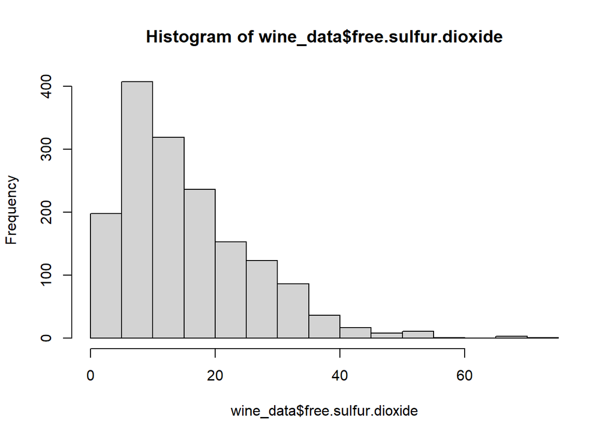

```r
hist(wine_data$free.sulfur.dioxide)
```

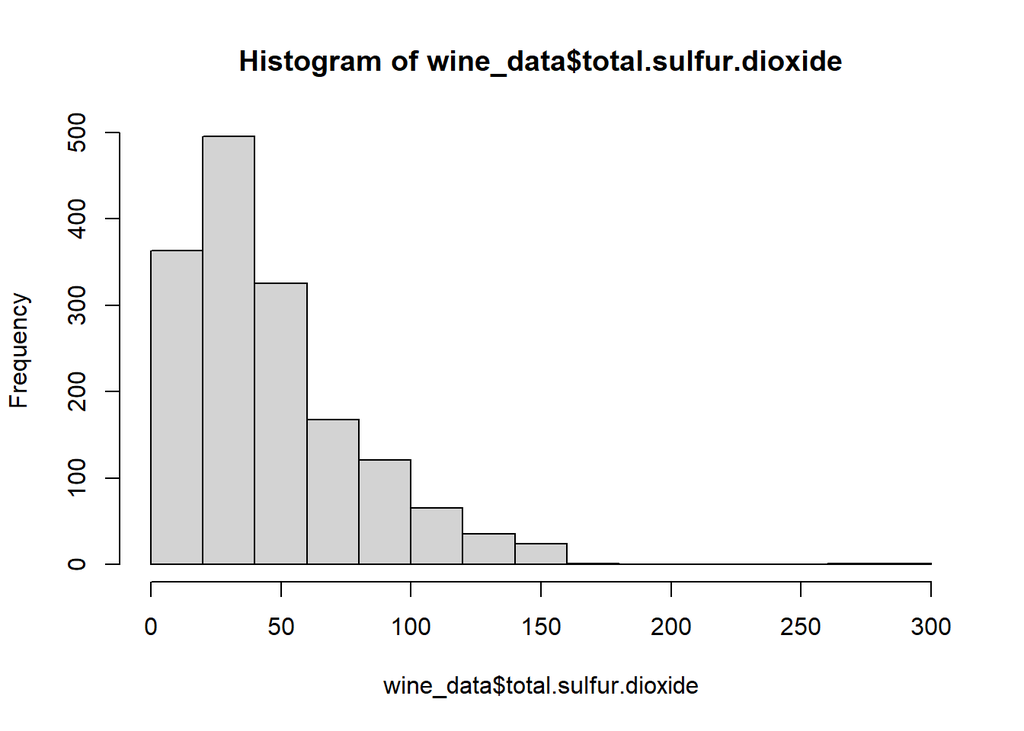

```r
hist(wine_data$total.sulfur.dioxide)
```

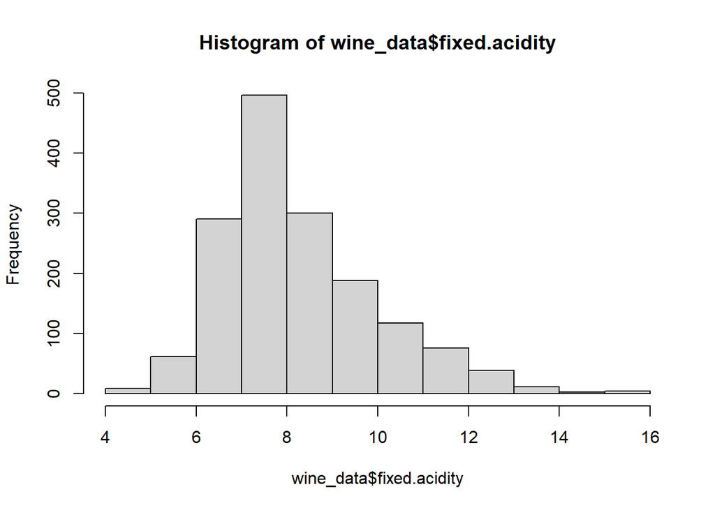

```r
#add in all other variables for a comprehensive exploration
hist(wine_data$fixed.acidity)
```

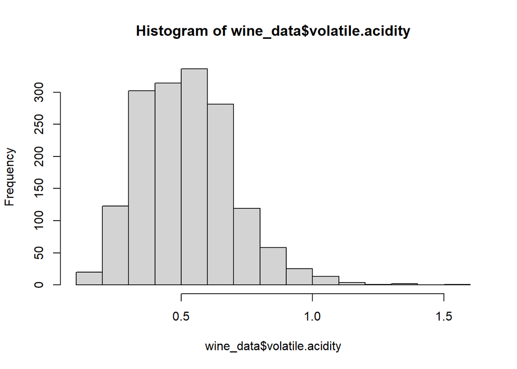

```r
hist(wine_data$volatile.acidity)
```

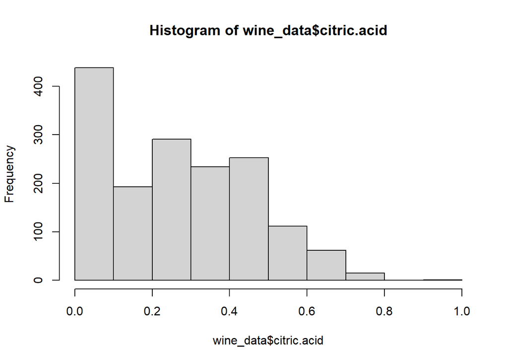

```r
hist(wine_data$citric.acid)
```

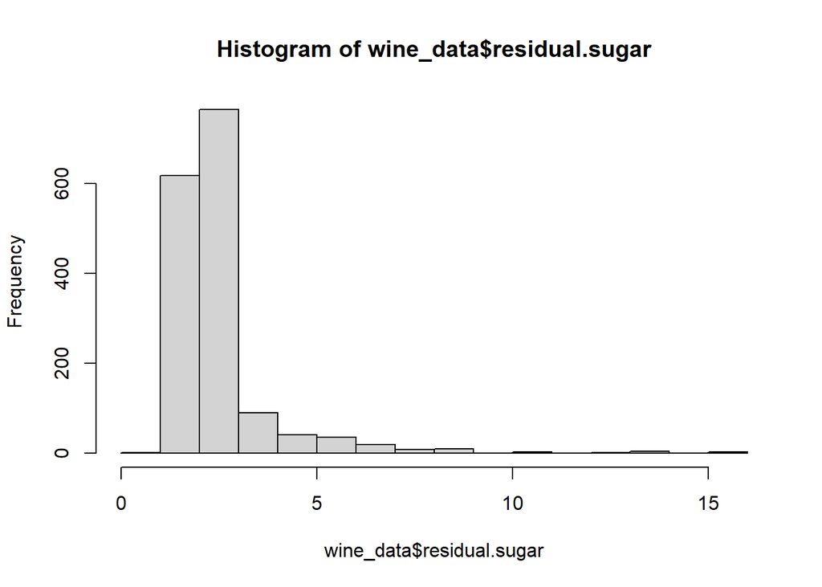

```r
hist(wine_data$residual.sugar)
```

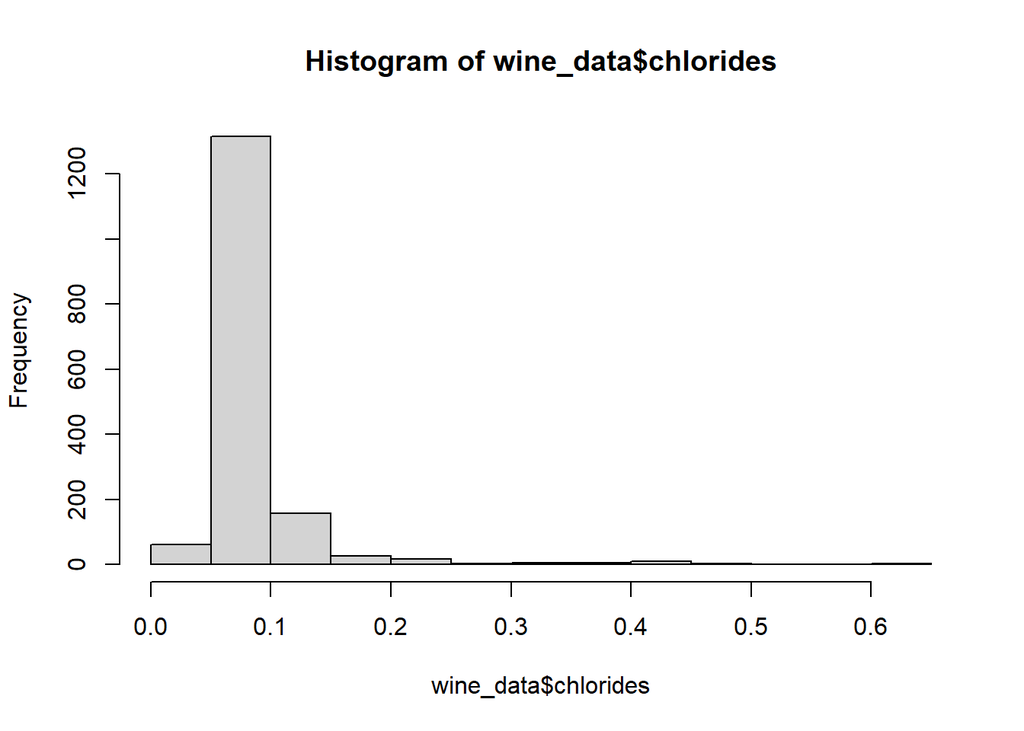

```r
hist(wine_data$chlorides)
```

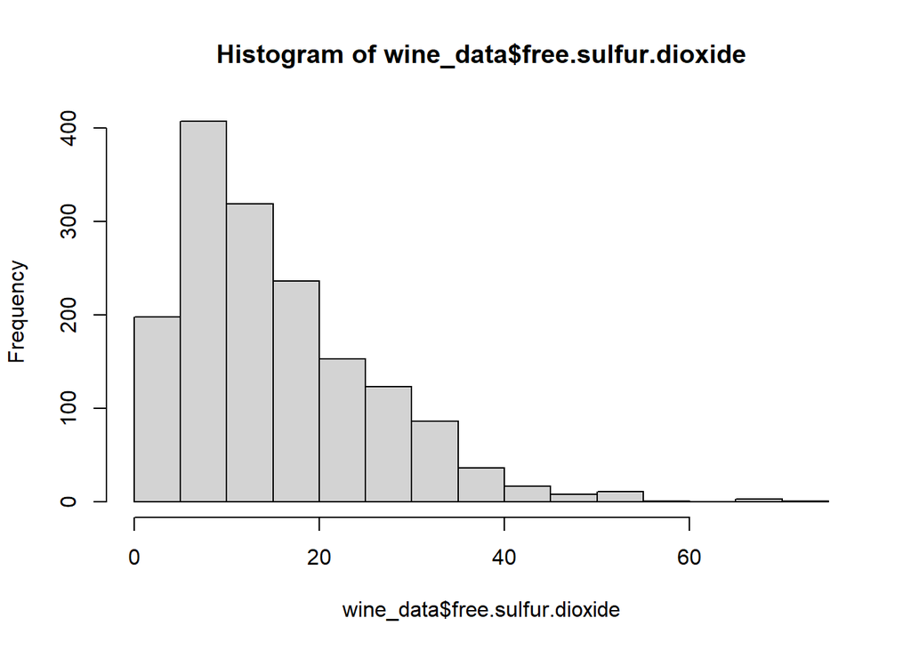

```r
hist(wine_data$free.sulfur.dioxide)
```

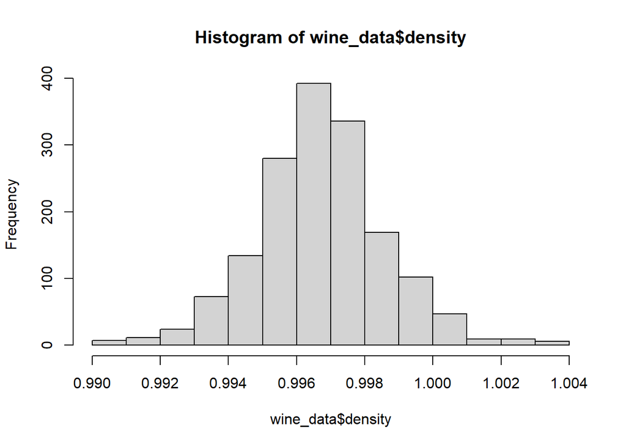

```r
hist(wine_data$density)
```

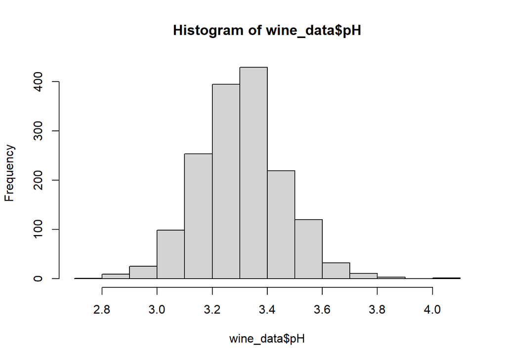

```r
hist(wine_data$pH)
```

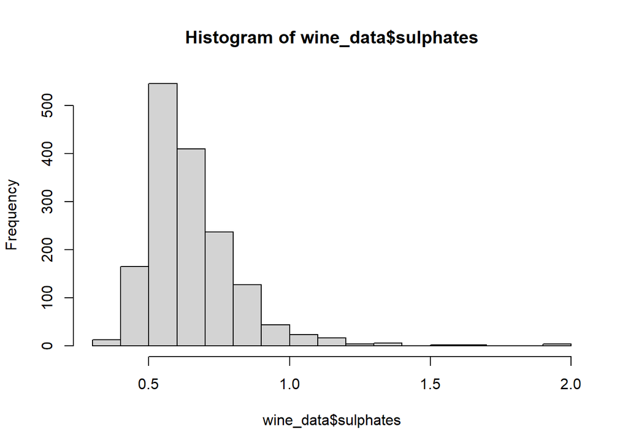

```r
hist(wine_data$sulphates)
```

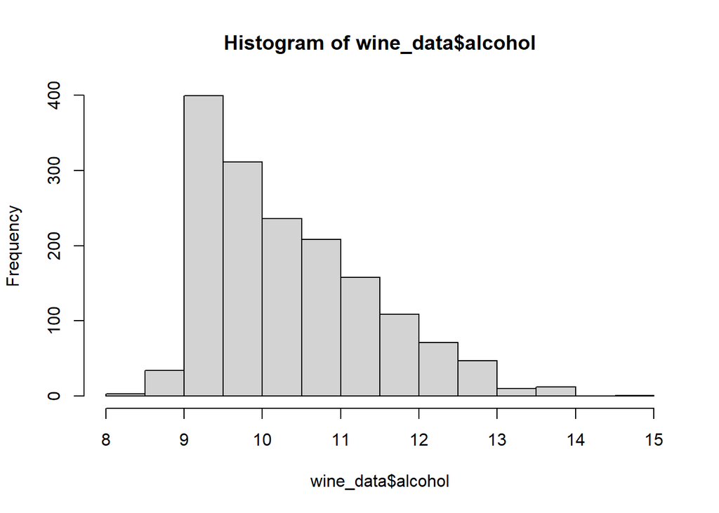

```r
hist(wine_data$alcohol)
```

```r
#we can tell that except from density and pH, the other variables are all right skewed
```

## 4. Data Preprocessing

There is no missing value in the dataset. Among the 1599 observations, 240 rows were duplicated entirely. Considering the 12 physicochemical properties variables are all at two decimal point precision, the likelihood of a complete duplicate existing in real life is low, so we removed these observations from the analysis. This study also combined Mahalanobis, Leverage, and Cooks Distance to define and remove 62 outliers rows, leaving 1297 observations in the dataset.

### 4.1 Checking for Data Completeness

```r
total_null <- colSums(is.na(wine_data))
total_null <- total_null[order(-total_null)]
percent_null <- colSums(is.na(wine_data)) / nrow(wine_data)
percent_null <- percent_null[order(-percent_null)]

missing_data <- data.frame("Total Number of Missing values" = total_null, "Percent of Missing values" = percent_null)
missing_data
```

```
##                      Total.Number.of.Missing.values Percent.of.Missing.values
## fixed.acidity                                     0                         0
## volatile.acidity                                  0                         0
## citric.acid                                       0                         0
## residual.sugar                                    0                         0
## chlorides                                         0                         0
## free.sulfur.dioxide                               0                         0
## total.sulfur.dioxide                              0                         0
## density                                           0                         0
## pH                                                0                         0
## sulphates                                         0                         0
## alcohol                                           0                         0
## quality                                           0                         0
```

There’s no missing values

### 4.2 Check for duplicates in dataset

```r
print(paste("Total Number of Duplicates", sum(duplicated(wine_data))))
```

```
## [1] "Total Number of Duplicates 240"
```

There are 240 duplicated rows

### 4.3 Removing Duplicates

```r
str(wine_data)
```

```
## 'data.frame':    1599 obs. of  12 variables:
##  $ fixed.acidity       : num  7.4 7.8 7.8 11.2 7.4 7.4 7.9 7.3 7.8 7.5 ...
##  $ volatile.acidity    : num  0.7 0.88 0.76 0.28 0.7 0.66 0.6 0.65 0.58 0.5 ...
##  $ citric.acid         : num  0 0 0.04 0.56 0 0 0.06 0 0.02 0.36 ...
##  $ residual.sugar      : num  1.9 2.6 2.3 1.9 1.9 1.8 1.6 1.2 2 6.1 ...
##  $ chlorides           : num  0.076 0.098 0.092 0.075 0.076 0.075 0.069 0.065 0.073 0.071 ...
##  $ free.sulfur.dioxide : num  11 25 15 17 11 13 15 15 9 17 ...
##  $ total.sulfur.dioxide: num  34 67 54 60 34 40 59 21 18 102 ...
##  $ density             : num  0.998 0.997 0.997 0.998 0.998 ...
##  $ pH                  : num  3.51 3.2 3.26 3.16 3.51 3.51 3.3 3.39 3.36 3.35 ...
##  $ sulphates           : num  0.56 0.68 0.65 0.58 0.56 0.56 0.46 0.47 0.57 0.8 ...
##  $ alcohol             : num  9.4 9.8 9.8 9.8 9.4 9.4 9.4 10 9.5 10.5 ...
##  $ quality             : int  5 5 5 6 5 5 5 7 7 5 ...
```

```r
wine_data_1 <-  unique(wine_data)
str(wine_data_1)
```

```
## 'data.frame':    1359 obs. of  12 variables:
##  $ fixed.acidity       : num  7.4 7.8 7.8 11.2 7.4 7.9 7.3 7.8 7.5 6.7 ...
##  $ volatile.acidity    : num  0.7 0.88 0.76 0.28 0.66 0.6 0.65 0.58 0.5 0.58 ...
##  $ citric.acid         : num  0 0 0.04 0.56 0 0.06 0 0.02 0.36 0.08 ...
##  $ residual.sugar      : num  1.9 2.6 2.3 1.9 1.8 1.6 1.2 2 6.1 1.8 ...
##  $ chlorides           : num  0.076 0.098 0.092 0.075 0.075 0.069 0.065 0.073 0.071 0.097 ...
##  $ free.sulfur.dioxide : num  11 25 15 17 13 15 15 9 17 15 ...
##  $ total.sulfur.dioxide: num  34 67 54 60 40 59 21 18 102 65 ...
##  $ density             : num  0.998 0.997 0.997 0.998 0.998 ...
##  $ pH                  : num  3.51 3.2 3.26 3.16 3.51 3.3 3.39 3.36 3.35 3.28 ...
##  $ sulphates           : num  0.56 0.68 0.65 0.58 0.56 0.46 0.47 0.57 0.8 0.54 ...
##  $ alcohol             : num  9.4 9.8 9.8 9.8 9.4 9.4 10 9.5 10.5 9.2 ...
##  $ quality             : int  5 5 5 6 5 5 7 7 5 5 ...
```

```r
dim(wine_data)
```

```
## [1] 1599   12
```

```r
dim(wine_data_1)
```

```
## [1] 1359   12
```

### 4.4 Removing outliers

#### 4.4.1 Mahalanobis

```r
#calculate the mahalanobis distances for each row in the data

mahal <- mahalanobis(wine_data_1,
                     colMeans(wine_data_1),
                     cov(wine_data_1))
#calculate the cutoff value by calculating the quantile of the  Chi-squared distribution based on the strict significance level of 0.001 and the degree of freedom as the number of variables/columns
cutmahal <- qchisq(1-.001, ncol(wine_data_1))

badmahal <- as.numeric(mahal > cutmahal) ##note the direction of the >
table(badmahal)
```

```
## badmahal
##    0    1
## 1306   53
```

#### 4.4.2 Leverage

```r
#To get the other outlier statistics, we have to use the regression model we wish to test. And in this case, we will use the lm() function with our regression formula.)
mod_1 <- lm(quality ~ ., data = wine_data_1)

k <- 11 ##number of IVs
leverage <- hatvalues(mod_1)
cutleverage <- (2*k+2) / nrow(wine_data_1)
badleverage <- as.numeric(leverage > cutleverage)
table(badleverage)
```

```
## badleverage
##    0    1
## 1259  100
```

#### 4.4.3 Cook’s Distance

```r
cooks <- cooks.distance(mod_1)
cutcooks <- 4 / (nrow(wine_data_1) - k - 1)
badcooks <- as.numeric(cooks > cutcooks)
table(badcooks)
```

```
## badcooks
##    0    1
## 1277   82
```

#### 4.4.4 Combined methods

```r
### Table with total score for the number of indicator that the data points have
totalout <- badmahal + badleverage + badcooks
table(totalout)
```

```
## totalout
##    0    1    2    3
## 1211   86   37   25
```

```r
wine_nooutliers <- subset(wine_data_1, totalout < 2)
str(wine_nooutliers)
```

```
## 'data.frame':    1297 obs. of  12 variables:
##  $ fixed.acidity       : num  7.4 7.8 7.8 11.2 7.4 7.9 7.3 7.8 7.5 6.7 ...
##  $ volatile.acidity    : num  0.7 0.88 0.76 0.28 0.66 0.6 0.65 0.58 0.5 0.58 ...
##  $ citric.acid         : num  0 0 0.04 0.56 0 0.06 0 0.02 0.36 0.08 ...
##  $ residual.sugar      : num  1.9 2.6 2.3 1.9 1.8 1.6 1.2 2 6.1 1.8 ...
##  $ chlorides           : num  0.076 0.098 0.092 0.075 0.075 0.069 0.065 0.073 0.071 0.097 ...
##  $ free.sulfur.dioxide : num  11 25 15 17 13 15 15 9 17 15 ...
##  $ total.sulfur.dioxide: num  34 67 54 60 40 59 21 18 102 65 ...
##  $ density             : num  0.998 0.997 0.997 0.998 0.998 ...
##  $ pH                  : num  3.51 3.2 3.26 3.16 3.51 3.3 3.39 3.36 3.35 3.28 ...
##  $ sulphates           : num  0.56 0.68 0.65 0.58 0.56 0.46 0.47 0.57 0.8 0.54 ...
##  $ alcohol             : num  9.4 9.8 9.8 9.8 9.4 9.4 10 9.5 10.5 9.2 ...
##  $ quality             : int  5 5 5 6 5 5 7 7 5 5 ...
```

## 5. Exploratory Data Analysis

### 5.1 Evaluating the dependent variable of wine quality

```r
summary(wine_nooutliers$quality)
```

```
##    Min. 1st Qu.  Median    Mean 3rd Qu.    Max.
##   3.000   5.000   6.000   5.636   6.000   8.000
```

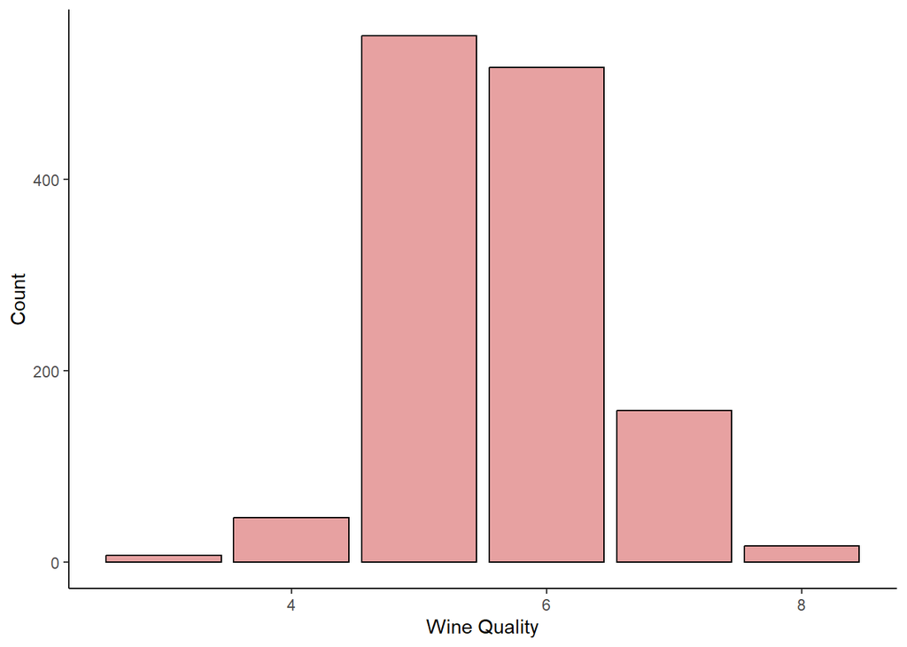

```r
ggplot(data= wine_nooutliers, aes(x=quality)) +
  geom_bar(color = "black",fill =  "#E7A1A1") +
  xlab("Wine Quality") +
  ylab ("Count") +
  theme_classic()
```

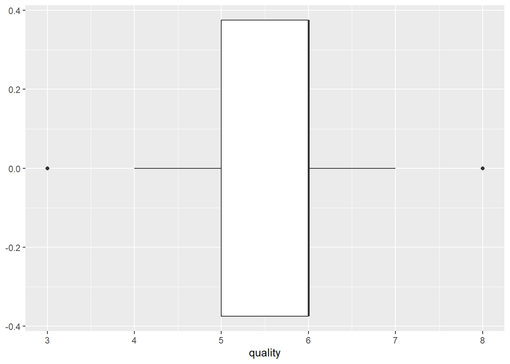

```r
ggplot(data= wine_nooutliers, aes(x=quality)) +
  geom_boxplot()
```

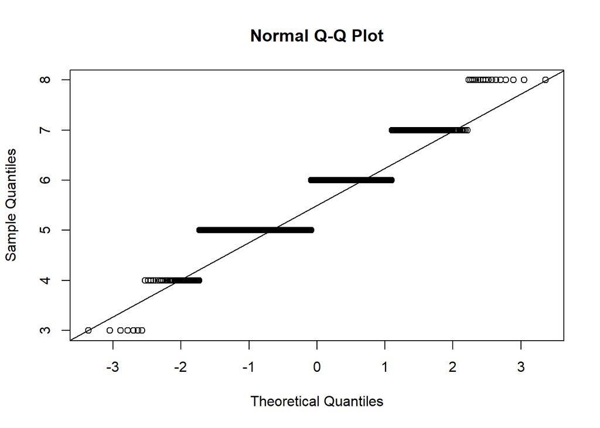

```r
qqnorm(wine_nooutliers$quality)
qqline(wine_nooutliers$quality)
```

```r
Skew_quality <-skewness(wine_nooutliers$quality)
print(paste("Skewness of wine quality: ",Skew_quality))
```

```
## [1] "Skewness of wine quality:  0.254854639485945"
```

```r
Kurt_quality <- kurtosis(wine_nooutliers$quality)
print(paste("Kurtosis of wine quality: ", Kurt_quality))
```

```
## [1] "Kurtosis of wine quality:  3.28166786068911"
```

The dependent variable in this study is Quality. Quality ranges from 3 to 8, mostly around 5 and 6.

The wine quality data is nearly normal distributed and confirmed further by calculating the skewness and kurtosis values.

Skewness measure a degree of asymmetry of data distribution that deviates from the symmetrical normal distribution. The value of skewness at 0.2 shows that the data are nearly symmetrical as 0 indicating normal distribution.

Kurtosis measures the heaviness of a distribution’s tails relative to a normal distribution. Since the standard normal distribution has kurtosis of 3, the calculated value of Kurtosis is 3.3 just slightly higher than 3 indicating a slightly positive Kurtosis, or leptokurtic

### 5.2 Evaluating independent variables

The 11 independent variables are mostly skewed to the right. Four properties showed an interesting relationship between the variable value and the quality score. Citric Acid, Alcohol, and Sulphates indicate a positive relation-ship with quality, showing that the higher these variables are, the higher the quality score. Meanwhile, volatile Acidi-ty presents a negative relationship with quality.

#### 5.2.1 Fixed acidity

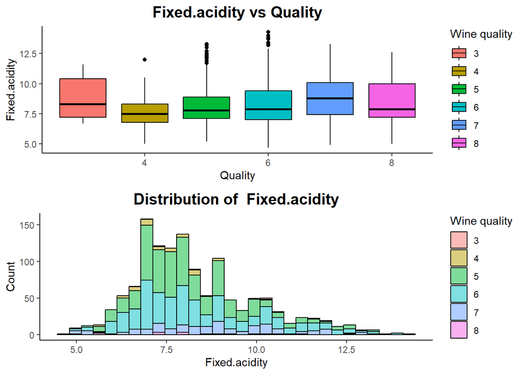

```r
box_hist_plot<- function(column)
  {
  boxplot_var<- ggplot(wine_nooutliers, aes(x = quality, y = .data[[column]], fill = factor(quality))) +
    geom_boxplot(color = "black") +
    ggtitle(paste(toTitleCase(column), "vs Quality")) +
    xlab ("Quality") +
    ylab (toTitleCase(column)) +
    scale_fill_discrete(name = "Wine quality") +
    theme_classic() +
    theme(plot.title = element_text(face = "bold", size = 15, hjust = 0.5))

  hist_var<- ggplot(wine_nooutliers, aes(x = .data[[column]], fill = factor(quality))) +
    geom_histogram (alpha = 0.5,color = 'black') +
    ggtitle(paste("Distribution of ",toTitleCase(column))) +
    xlab(toTitleCase(column))+
    ylab ("Count") +
    scale_fill_discrete(name = "Wine quality") +
    theme_classic() +
    theme(plot.title = element_text(face = "bold", size = 15, hjust = 0.5))

  gridExtra::grid.arrange(boxplot_var, hist_var, ncol = 1)

}


skew_kurt_cal <- function(data, variable_name) {
  skew <- skewness(data[[variable_name]])
  kurt <- kurtosis(data[[variable_name]])

  print(paste("Skewness of", toTitleCase(variable_name), ":", skew))
  print(paste("Kurtosis of", toTitleCase(variable_name), ":", kurt))
}


box_hist_plot("fixed.acidity")
```

```r
skew_kurt_cal(wine_nooutliers,"fixed.acidity")
```

```
## [1] "Skewness of Fixed.acidity : 0.812251657492325"
## [1] "Kurtosis of Fixed.acidity : 3.38727029151103"
```

-nearly normal distributed -slightly right skewed

#### 5.2.2 Volatile acidity

```r
str(wine_nooutliers)
```

```
## 'data.frame':    1297 obs. of  12 variables:
##  $ fixed.acidity       : num  7.4 7.8 7.8 11.2 7.4 7.9 7.3 7.8 7.5 6.7 ...
##  $ volatile.acidity    : num  0.7 0.88 0.76 0.28 0.66 0.6 0.65 0.58 0.5 0.58 ...
##  $ citric.acid         : num  0 0 0.04 0.56 0 0.06 0 0.02 0.36 0.08 ...
##  $ residual.sugar      : num  1.9 2.6 2.3 1.9 1.8 1.6 1.2 2 6.1 1.8 ...
##  $ chlorides           : num  0.076 0.098 0.092 0.075 0.075 0.069 0.065 0.073 0.071 0.097 ...
##  $ free.sulfur.dioxide : num  11 25 15 17 13 15 15 9 17 15 ...
##  $ total.sulfur.dioxide: num  34 67 54 60 40 59 21 18 102 65 ...
##  $ density             : num  0.998 0.997 0.997 0.998 0.998 ...
##  $ pH                  : num  3.51 3.2 3.26 3.16 3.51 3.3 3.39 3.36 3.35 3.28 ...
##  $ sulphates           : num  0.56 0.68 0.65 0.58 0.56 0.46 0.47 0.57 0.8 0.54 ...
##  $ alcohol             : num  9.4 9.8 9.8 9.8 9.4 9.4 10 9.5 10.5 9.2 ...
##  $ quality             : int  5 5 5 6 5 5 7 7 5 5 ...
```

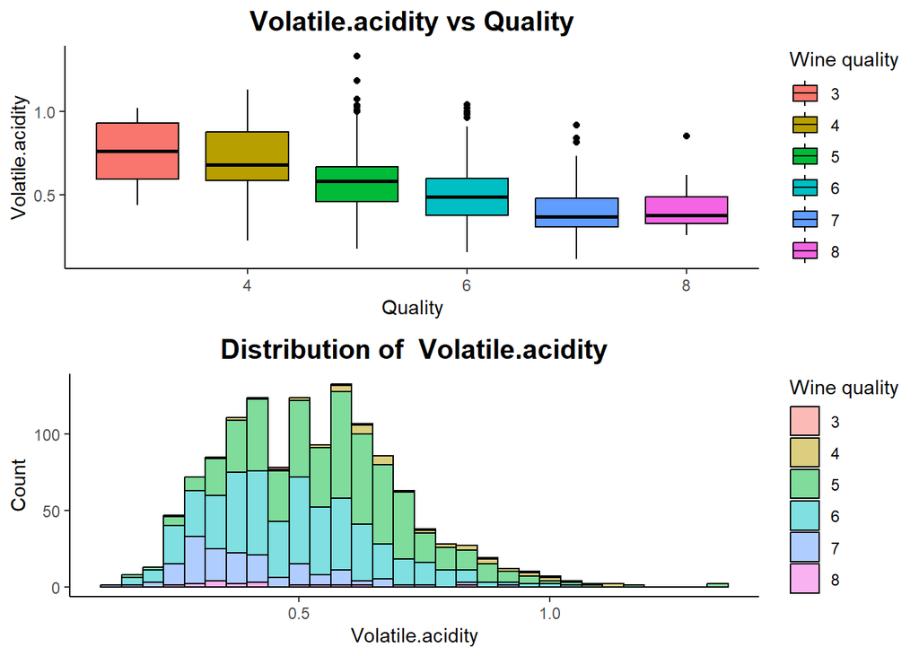

```r
box_hist_plot("volatile.acidity")
```

```r
skew_kurt_cal(wine_nooutliers,"volatile.acidity")
```

```
## [1] "Skewness of Volatile.acidity : 0.58309033007414"
## [1] "Kurtosis of Volatile.acidity : 3.5116629597899"
```

- nearly normal distributed
- right skewed

#### 5.2.3 Citric acid

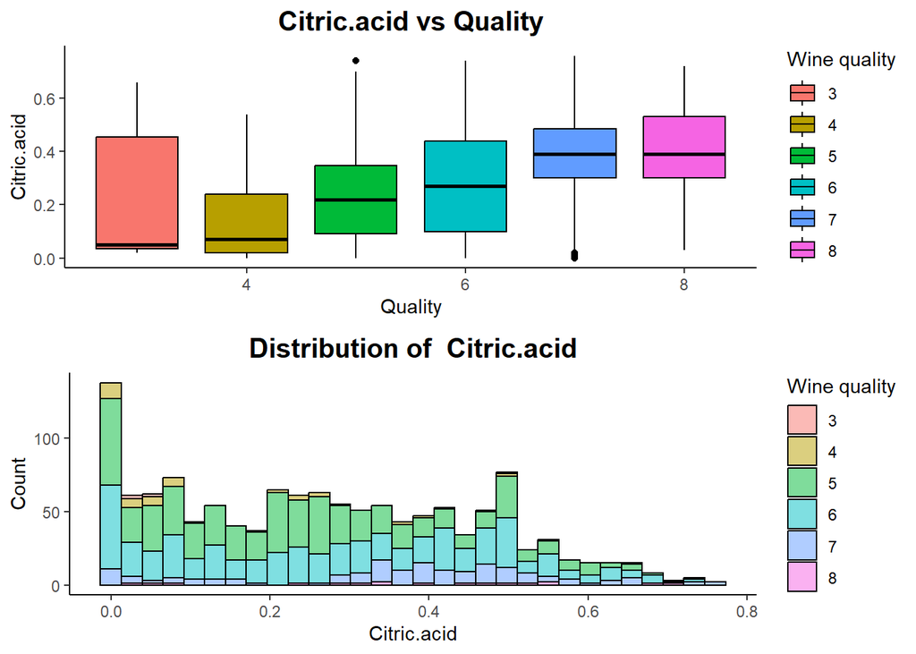

```r
box_hist_plot("citric.acid")
```

```r
skew_kurt_cal(wine_nooutliers,"citric.acid")
```

```
## [1] "Skewness of Citric.acid : 0.273152531115366"
## [1] "Kurtosis of Citric.acid : 2.05994467144349"
```

-right skewed

#### 5.2.4 Residual.sugar

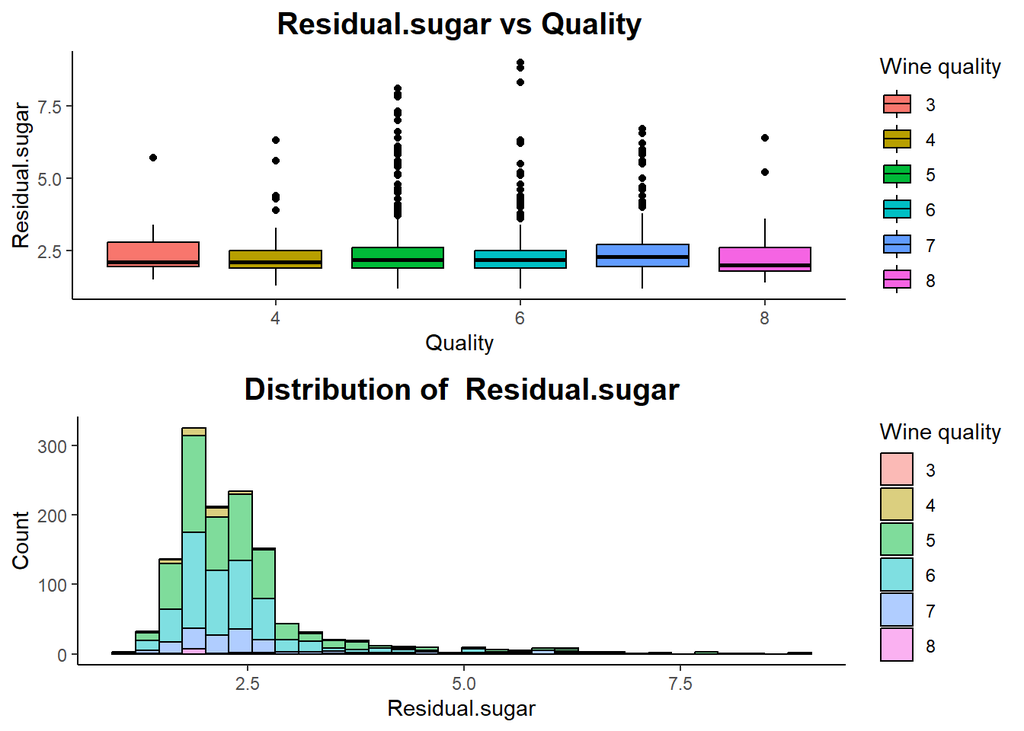

```r
box_hist_plot("residual.sugar")
```

```r
skew_kurt_cal(wine_nooutliers,"residual.sugar")
```

```
## [1] "Skewness of Residual.sugar : 2.8878291915301"
## [1] "Kurtosis of Residual.sugar : 13.5963653470142"
```

- nearly normal distributed
- highly right skewed because of outliers

#### 5.2.5 Chlorides

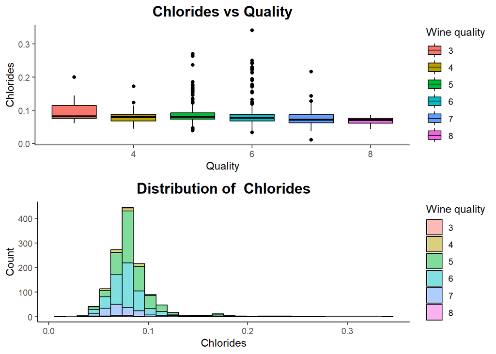

```r
box_hist_plot("chlorides")
```

```r
skew_kurt_cal(wine_nooutliers,"chlorides")
```

```
## [1] "Skewness of Chlorides : 3.27930651513361"
## [1] "Kurtosis of Chlorides : 21.3964950284356"
```

- nearly normal distributed
- highly right skewed because of outliers

#### 5.2.6 Free sulfur dioxide

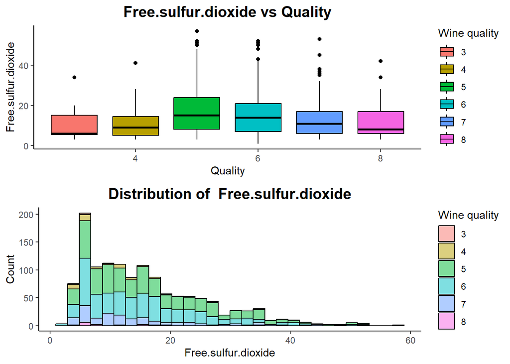

```r
box_hist_plot("free.sulfur.dioxide")
```

```r
skew_kurt_cal(wine_nooutliers,"free.sulfur.dioxide")
```

```
## [1] "Skewness of Free.sulfur.dioxide : 1.03360098662839"
## [1] "Kurtosis of Free.sulfur.dioxide : 3.80169958953512"
```

- highly right skewed because of outliers

#### 5.2.7 Total.sulfur.dioxide

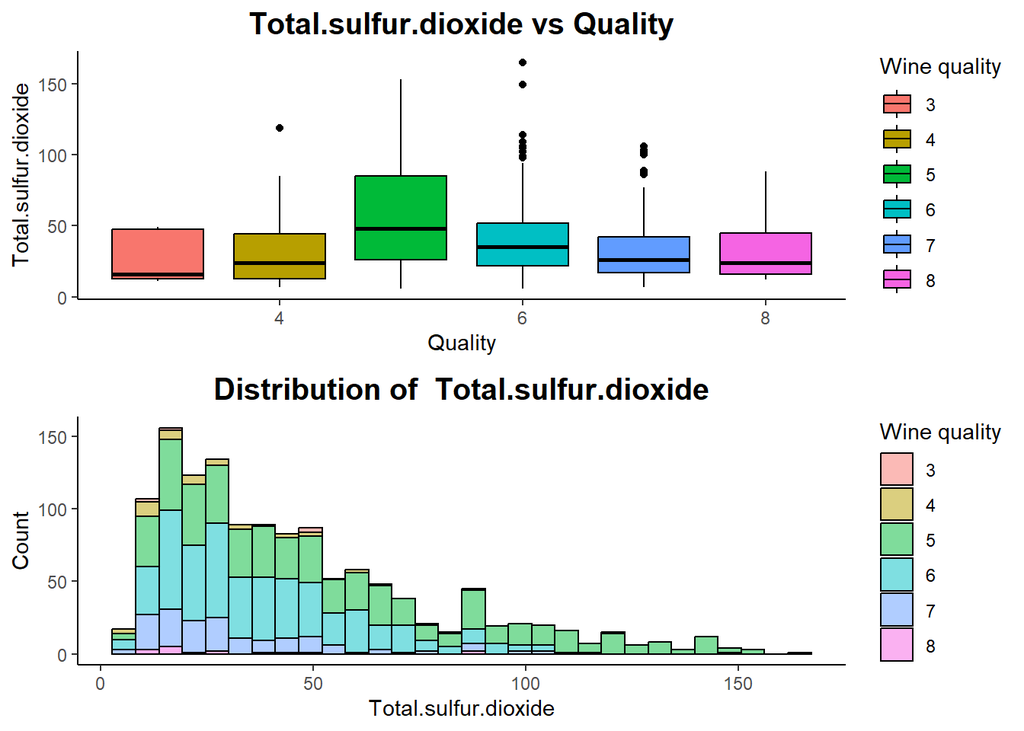

```r
box_hist_plot("total.sulfur.dioxide")
```

```r
skew_kurt_cal(wine_nooutliers,"total.sulfur.dioxide")
```

```
## [1] "Skewness of Total.sulfur.dioxide : 1.18709122022082"
## [1] "Kurtosis of Total.sulfur.dioxide : 3.95028908579744"
```

- highly right skewed because of outliers

#### 5.2.8 Density

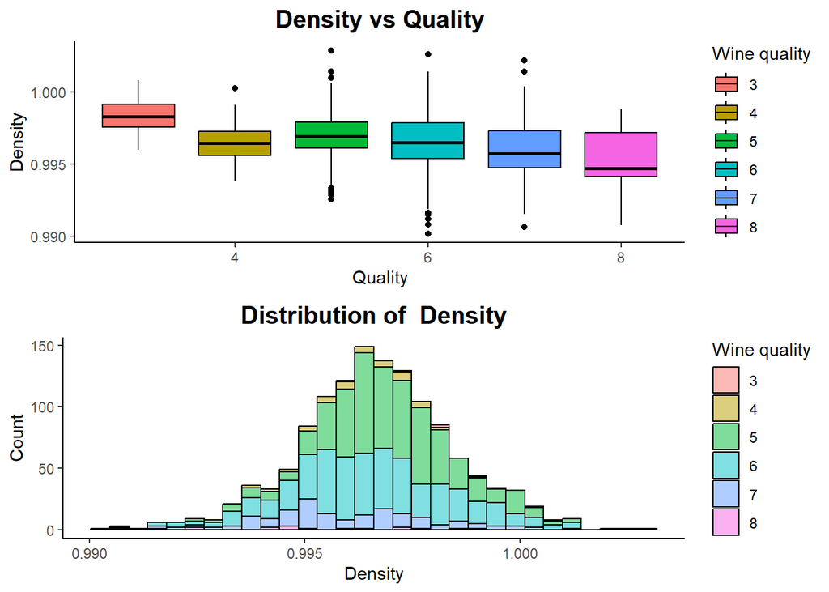

```r
box_hist_plot("density")
```

```r
skew_kurt_cal(wine_nooutliers,"density")
```

```
## [1] "Skewness of Density : -0.0889634395909149"
## [1] "Kurtosis of Density : 3.50053421994161"
```

- normal distributed
- skewness is nearly 0

#### 5.2.9 pH

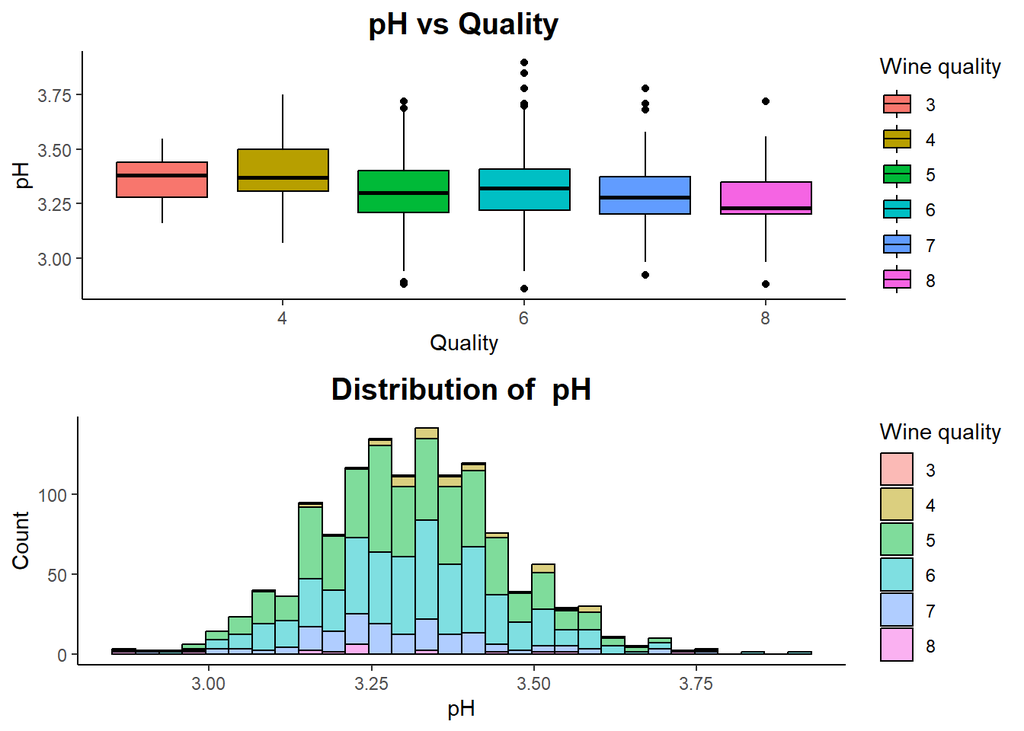

```r
box_hist_plot("pH")
```

```r
skew_kurt_cal(wine_nooutliers,"pH")
```

```
## [1] "Skewness of pH : 0.205642803030624"
## [1] "Kurtosis of pH : 3.29896330258142"
```

#### 5.2.10 Sulphates

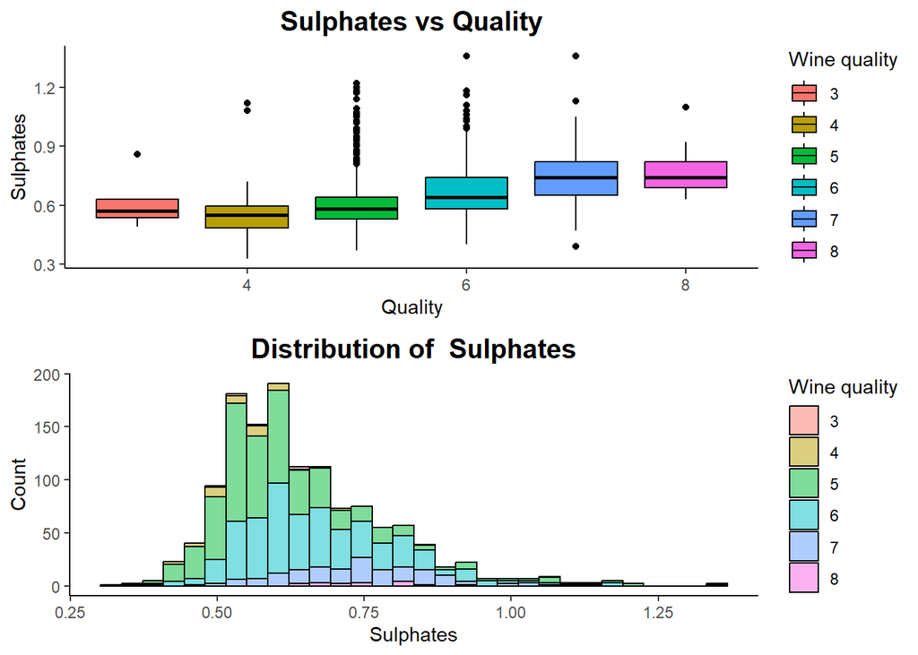

```r
box_hist_plot("sulphates")
```

```r
skew_kurt_cal(wine_nooutliers,"sulphates")
```

```
## [1] "Skewness of Sulphates : 1.19695186393763"
## [1] "Kurtosis of Sulphates : 5.14923463407756"
```

- nearly normal distributed
- highly right skewed because of outliers

#### 5.2.11 alcohol

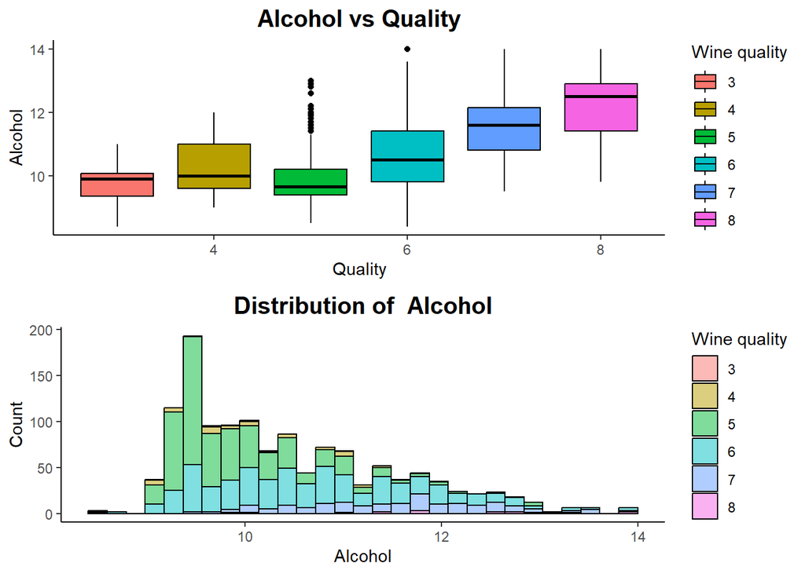

```r
box_hist_plot("alcohol")
```

```r
skew_kurt_cal(wine_nooutliers,"alcohol")
```

```
## [1] "Skewness of Alcohol : 0.834768100957239"
## [1] "Kurtosis of Alcohol : 3.0621640386092"
```

### 5.3 Correlation

To understand the correlation between the variables, a correlation analysis is conducted. Some variables demon-strated a higher correlation with quality than others. Alco-hol shows a positive correlation at 0.51, with quality as the number one physicochemical property, followed by Sul-phates with a 0.35 correlation score and Citric Acid with a 0.24 correlation. Volatile Acidity shows a negative correla-tion with quality, with a -0.39 correlation score. From a chemical perspective, this research also considered the correlation between the independent variables. Fixed Acid-ity positively correlates with Citric Acid (0.7) and Density (0.66). However, there’s no multicollinearity existed

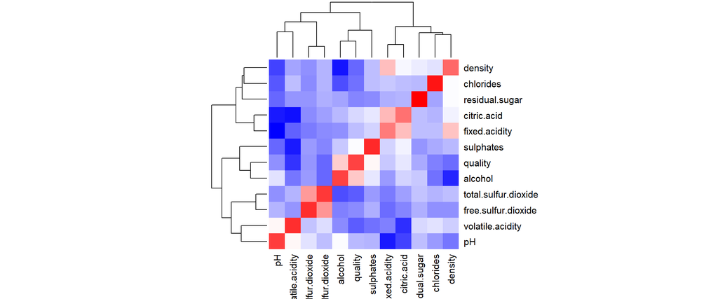

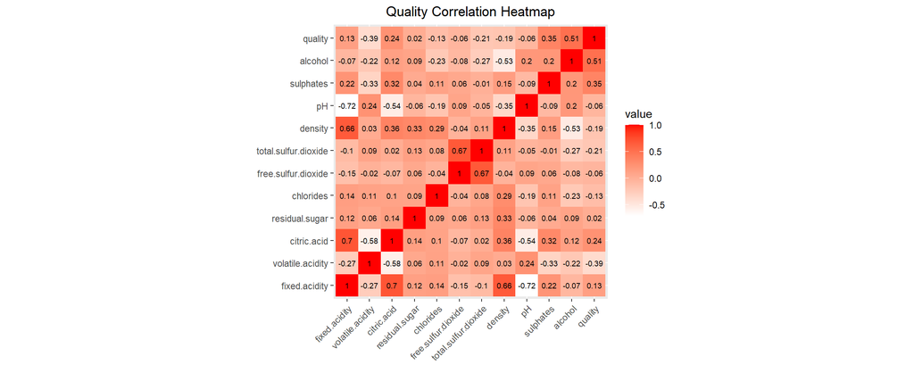

```
##                      fixed.acidity volatile.acidity citric.acid residual.sugar
## fixed.acidity                 1.00            -0.27        0.70           0.12
## volatile.acidity             -0.27             1.00       -0.58           0.06
## citric.acid                   0.70            -0.58        1.00           0.14
## residual.sugar                0.12             0.06        0.14           1.00
## chlorides                     0.14             0.11        0.10           0.09
## free.sulfur.dioxide          -0.15            -0.02       -0.07           0.06
## total.sulfur.dioxide         -0.10             0.09        0.02           0.13
## density                       0.66             0.03        0.36           0.33
## pH                           -0.72             0.24       -0.54          -0.06
## sulphates                     0.22            -0.33        0.32           0.04
## alcohol                      -0.07            -0.22        0.12           0.09
## quality                       0.13            -0.39        0.24           0.02
##                      chlorides free.sulfur.dioxide total.sulfur.dioxide density
## fixed.acidity             0.14               -0.15                -0.10    0.66
## volatile.acidity          0.11               -0.02                 0.09    0.03
## citric.acid               0.10               -0.07                 0.02    0.36
## residual.sugar            0.09                0.06                 0.13    0.33
## chlorides                 1.00               -0.04                 0.08    0.29
## free.sulfur.dioxide      -0.04                1.00                 0.67   -0.04
## total.sulfur.dioxide      0.08                0.67                 1.00    0.11
## density                   0.29               -0.04                 0.11    1.00
## pH                       -0.19                0.09                -0.05   -0.35
## sulphates                 0.11                0.06                -0.01    0.15
## alcohol                  -0.23               -0.08                -0.27   -0.53
## quality                  -0.13               -0.06                -0.21   -0.19
##                         pH sulphates alcohol quality
## fixed.acidity        -0.72      0.22   -0.07    0.13
## volatile.acidity      0.24     -0.33   -0.22   -0.39
## citric.acid          -0.54      0.32    0.12    0.24
## residual.sugar       -0.06      0.04    0.09    0.02
## chlorides            -0.19      0.11   -0.23   -0.13
## free.sulfur.dioxide   0.09      0.06   -0.08   -0.06
## total.sulfur.dioxide -0.05     -0.01   -0.27   -0.21
## density              -0.35      0.15   -0.53   -0.19
## pH                    1.00     -0.09    0.20   -0.06
## sulphates            -0.09      1.00    0.20    0.35
## alcohol               0.20      0.20    1.00    0.51
## quality              -0.06      0.35    0.51    1.00
##
```

[output cut: 28 more lines]

```
## alcohol              0.0000    0.0037              0.0000               0.0000
## quality              0.0000    0.0350              0.0000               0.0000
##                      pH     sulphates alcohol quality
## fixed.acidity        0.0000 0.0000    0.0073  0.0000
## volatile.acidity     0.0000 0.0000    0.0000  0.0000
## citric.acid          0.0000 0.0000    0.0000  0.0000
## residual.sugar       0.0265 0.2038    0.0007  0.5553
## chlorides            0.0000 0.0001    0.0000  0.0000
## free.sulfur.dioxide  0.0019 0.0394    0.0037  0.0350
## total.sulfur.dioxide 0.1045 0.7444    0.0000  0.0000
## density              0.0000 0.0000    0.0000  0.0000
## pH                          0.0007    0.0000  0.0233
## sulphates            0.0007           0.0000  0.0000
## alcohol              0.0000 0.0000            0.0000
## quality              0.0233 0.0000    0.0000
```

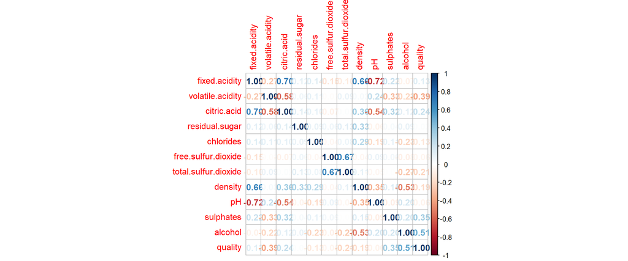

Target variable Quality has high correlation to alcohol, volatile acidity, sulphates, and citric acid properties

Beside, independent variables also have correlation to each other including - Fixed Acidity has high correlation to pH, citric acid, density - Volatile Acidity has high correlation to citric acid - Free Sulfur Dioxide has high correlation with total sulfur dioxide

There’s no multicollinearity exist among the independent variables.

### 5.4 t-test

Based on previous descriptive analysis, the median wine quality of the observations in this dataset is 6.0. Based on this fact, the dataset is in the bad (quality < 6) and the good quality group (quality >= 6). Before building the linear regression models, we performed an independent two-sample t-test to evaluate the difference in the four potential physical properties between the good and the bad wine better to understand the correlation between quality and physical properties. The four potential proper-ties studied in this t-test have the highest correlation coef-ficients with quality variables, including alcohol, sulfates, volatile acidity, and citric acid. In this test, the Null hypothesis states that the means are the same for the two quality groups. According to the four t-test results, we have sufficient evidence to prove significant differences in the means of the four property values between the bad and good quality groups at a 95% confidence level. The rejection of the null hypothesis above lays the foundation for further analysis.

#### 5.4.1 Check Homogeneity assumption

```r
mod_2 <- lm(quality ~., data = wine_nooutliers)

summary(mod_2, correlation = TRUE)
```

```
##
## Call:
## lm(formula = quality ~ ., data = wine_nooutliers)
##
## Residuals:
##      Min       1Q   Median       3Q      Max
## -2.75379 -0.35941 -0.04034  0.43237  1.92678
##
## Coefficients:
##                        Estimate Std. Error t value Pr(>|t|)
## (Intercept)           1.970e+01  2.539e+01   0.776  0.43777
## fixed.acidity         3.233e-02  3.043e-02   1.062  0.28828
## volatile.acidity     -1.057e+00  1.367e-01  -7.731 2.14e-14 ***
## citric.acid          -3.338e-01  1.681e-01  -1.986  0.04730 *
## residual.sugar        6.498e-03  2.309e-02   0.281  0.77848
## chlorides            -1.025e+00  7.335e-01  -1.398  0.16235
## free.sulfur.dioxide   2.584e-03  2.514e-03   1.028  0.30420
## total.sulfur.dioxide -2.517e-03  8.545e-04  -2.946  0.00328 **
## density              -1.592e+01  2.590e+01  -0.615  0.53891
## pH                   -4.803e-01  2.245e-01  -2.140  0.03255 *
## sulphates             1.197e+00  1.457e-01   8.219 4.98e-16 ***
## alcohol               3.007e-01  3.110e-02   9.671  < 2e-16 ***
## ---
## Signif. codes:  0 '***' 0.001 '**' 0.01 '*' 0.05 '.' 0.1 ' ' 1
##
## Residual standard error: 0.6382 on 1285 degrees of freedom
## Multiple R-squared:  0.3887, Adjusted R-squared:  0.3834
## F-statistic: 74.27 on 11 and 1285 DF,  p-value: < 2.2e-16
##
## Correlation of Coefficients:
##                      (Intercept) fixed.acidity volatile.acidity citric.acid
## fixed.acidity         0.76
## volatile.acidity      0.10       -0.08
## citric.acid           0.01       -0.34          0.55
## residual.sugar        0.58        0.41         -0.06            -0.07
## chlorides             0.16        0.18         -0.16            -0.11
## free.sulfur.dioxide  -0.08       -0.11          0.16             0.17
## total.sulfur.dioxide  0.07        0.22         -0.19            -0.26
## density              -1.00       -0.77         -0.10            -0.01
## pH                    0.55        0.73         -0.04             0.04
```

[output cut: 11 more lines]

```
## pH                    0.30           0.19     -0.11
## sulphates             0.16          -0.12     -0.09
## alcohol              -0.53           0.00      0.00
##                      total.sulfur.dioxide density pH    sulphates
## fixed.acidity
## volatile.acidity
## citric.acid
## residual.sugar
## chlorides
## free.sulfur.dioxide
## total.sulfur.dioxide
## density              -0.08
## pH                    0.16                -0.57
## sulphates             0.01                -0.24    0.05
## alcohol               0.12                 0.78   -0.51 -0.29
```

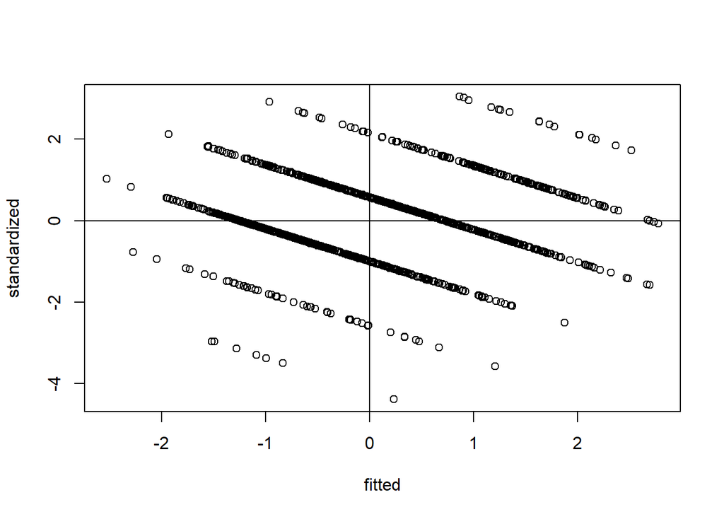

```r
standardized <- rstudent(mod_2)
fitted <- scale(mod_2$fitted.values)

{plot(fitted, standardized)
  abline(0,0)
  abline(v = 0)}
```

#### 5.4.2 Split Transformed Wine Data in to Higher Quality and Lower Quality

```r
table(wine_nooutliers$quality)
```

```
##
##   3   4   5   6   7   8
##   7  47 550 517 159  17
```

```r
wine_higher_quality = wine_nooutliers[wine_nooutliers$quality >= 6,]
wine_lower_quality = wine_nooutliers[wine_nooutliers$quality < 6, ]
```

#### 5.4.2 t-test

- Two-sample t-test to determine whether there is a significant difference between the two groups’ means.
- Null hypothesis: Assume the two means are the same.

##### 5.4.2.1 Alcohol

```r
t.test(wine_higher_quality$alcohol, wine_lower_quality$alcohol, var.equal = FALSE)
```

```
##
##  Welch Two Sample t-test
##
## data:  wine_higher_quality$alcohol and wine_lower_quality$alcohol
## t = 19.293, df = 1206.7, p-value < 2.2e-16
## alternative hypothesis: true difference in means is not equal to 0
## 95 percent confidence interval:
##  0.8888334 1.0900681
## sample estimates:
## mean of x mean of y
## 10.894252  9.904801
```

- Reject null hypothesis, there’s significant difference between Higher Quality and Lower Quality wine

##### 5.4.2.2 Volatile Acidity

```r
t.test(wine_higher_quality$volatile.acidity, wine_lower_quality$volatile.acidity, var.equal = FALSE)
```

```
##
##  Welch Two Sample t-test
##
## data:  wine_higher_quality$volatile.acidity and wine_lower_quality$volatile.acidity
## t = -12.67, df = 1229.5, p-value < 2.2e-16
## alternative hypothesis: true difference in means is not equal to 0
## 95 percent confidence interval:
##  -0.1376456 -0.1007325
## sample estimates:
## mean of x mean of y
##  0.471912  0.591101
```

- Reject null hypothesis, there’s significant difference between Higher Quality and Lower Quality wine

##### 5.4.2.3 Sulphates

```r
t.test(wine_higher_quality$sulphates, wine_lower_quality$sulphates, var.equal = FALSE)
```

```
##
##  Welch Two Sample t-test
##
## data:  wine_higher_quality$sulphates and wine_lower_quality$sulphates
## t = 11.741, df = 1282.5, p-value < 2.2e-16
## alternative hypothesis: true difference in means is not equal to 0
## 95 percent confidence interval:
##  0.0722477 0.1012339
## sample estimates:
## mean of x mean of y
## 0.6872872 0.6005464
```

- Reject null hypothesis, there’s significant difference between Higher Quality and Lower Quality wine

##### 5.4.2.4 Citric Acid

```r
t.test(wine_higher_quality$citric.acid, wine_lower_quality$citric.acid, var.equal = TRUE)
```

```
##
##  Two Sample t-test
##
## data:  wine_higher_quality$citric.acid and wine_lower_quality$citric.acid
## t = 6.8988, df = 1295, p-value = 8.18e-12
## alternative hypothesis: true difference in means is not equal to 0
## 95 percent confidence interval:
##  0.05151418 0.09245384
## sample estimates:
## mean of x mean of y
## 0.2991198 0.2271358
```

- Reject null hypothesis, there’s significant difference between Higher Quality and Lower Quality wine

## 6. Data Processing to meet model requirement

### 6.1. Assumptions

Assumption testing of linearity, additivity, and normality is essential to regression analysis, specifically for linear re-gression models. These assumptions serve as the founda-tion for the validity and reliability of regression results. This study found that the dataset met the additivity, lineari-ty, homogeneity, and homoscedasticity assumptions. However, with highly skewed data, the normality assump-tion still needs to be met. The insight led us to the neces-sary next step to normalize our variables.

#### 6.1.1 Additivity Assumption

```r
#symnum correlation table
correlation <- cor(wine_nooutliers)#correlation matrix
print(correlation)
```

```
##                      fixed.acidity volatile.acidity citric.acid residual.sugar
## fixed.acidity           1.00000000      -0.27040120  0.69587721     0.12337352
## volatile.acidity       -0.27040120       1.00000000 -0.57935658     0.06005187
## citric.acid             0.69587721      -0.57935658  1.00000000     0.13704514
## residual.sugar          0.12337352       0.06005187  0.13704514     1.00000000
## chlorides               0.13788452       0.10739226  0.10320736     0.09110719
## free.sulfur.dioxide    -0.15322762      -0.01669530 -0.07124002     0.06053460
## total.sulfur.dioxide   -0.10400082       0.08538422  0.01663008     0.12624625
## density                 0.66250221       0.03306524  0.36198172     0.32654472
## pH                     -0.71511216       0.24136054 -0.54272436    -0.06162602
## sulphates               0.22378155      -0.32561792  0.31726996     0.03531182
## alcohol                -0.07441891      -0.21992400  0.12377290     0.09432407
## quality                 0.13111170      -0.39197227  0.24402001     0.01639327
##                        chlorides free.sulfur.dioxide total.sulfur.dioxide
## fixed.acidity         0.13788452         -0.15322762         -0.104000819
## volatile.acidity      0.10739226         -0.01669530          0.085384220
## citric.acid           0.10320736         -0.07124002          0.016630082
## residual.sugar        0.09110719          0.06053460          0.126246247
## chlorides             1.00000000         -0.04036345          0.076906599
## free.sulfur.dioxide  -0.04036345          1.00000000          0.673547255
## total.sulfur.dioxide  0.07690660          0.67354726          1.000000000
## density               0.28611581         -0.04257494          0.106771165
## pH                   -0.19453936          0.08621605         -0.045095703
## sulphates             0.10622150          0.05721093         -0.009062707
## alcohol              -0.22997316         -0.08049242         -0.270732614
## quality              -0.12745684         -0.05856441         -0.214131245
##                          density          pH    sulphates     alcohol
## fixed.acidity         0.66250221 -0.71511216  0.223781546 -0.07441891
## volatile.acidity      0.03306524  0.24136054 -0.325617920 -0.21992400
## citric.acid           0.36198172 -0.54272436  0.317269965  0.12377290
## residual.sugar        0.32654472 -0.06162602  0.035311819  0.09432407
## chlorides             0.28611581 -0.19453936  0.106221495 -0.22997316
## free.sulfur.dioxide  -0.04257494  0.08621605  0.057210927 -0.08049242
## total.sulfur.dioxide  0.10677117 -0.04509570 -0.009062707 -0.27073261
## density               1.00000000 -0.35188858  0.147544726 -0.52904861
## pH                   -0.35188858  1.00000000 -0.093524252  0.19658627
## sulphates             0.14754473 -0.09352425  1.000000000  0.20038313
## alcohol              -0.52904861  0.19658627  0.200383127  1.00000000
## quality              -0.19409755 -0.06299425  0.352911090  0.50639877
##                          quality
## fixed.acidity         0.13111170
## volatile.acidity     -0.39197227
## citric.acid           0.24402001
## residual.sugar        0.01639327
## chlorides            -0.12745684
## free.sulfur.dioxide  -0.05856441
## total.sulfur.dioxide -0.21413124
## density              -0.19409755
## pH                   -0.06299425
## sulphates             0.35291109
## alcohol               0.50639877
## quality               1.00000000
```

```r
symnum(correlation,symbols = c("| ", ".", ",", "+", "*", "B"))# B represents strongest correlation,  | represents weakest correlation
```

```
##                      fx. v  c. r  ch f.. t  d  p  s  a q
## fixed.acidity        1
## volatile.acidity     |   1
## citric.acid          ,   .  1
## residual.sugar       |   |  |  1
## chlorides            |   |  |  |  1
## free.sulfur.dioxide  |   |  |  |  |  1
## total.sulfur.dioxide |   |  |  |  |  ,   1
## density              ,   |  .  .  |  |   |  1
## pH                   ,   |  .  |  |  |   |  .  1
## sulphates            |   .  .  |  |  |   |  |  |  1
## alcohol              |   |  |  |  |  |   |  .  |  |  1
## quality              |   .  |  |  |  |   |  |  |  .  . 1
## attr(,"legend")
## [1] 0 '| ' 0.3 '.' 0.6 ',' 0.8 '+' 0.9 '*' 0.95 'B' 1
```

The assumption for additivity is met